# Global-Music-Streaming-Listener-Analysis

Name - Shweta Raut Student Number - 24201146 Email ID - shweta.raut@ucdconnect.ie Study Programme - MSc Information Systems Year: 2024-25

```python
import pandas as pd
import numpy as np
import matplotlib.pyplot as plt
import seaborn as sns
from datetime import datetime
```

- Loads necessary libraries for data processing, visualization, and statistical analysis.
- The data processing application utilizes pandas for data manipulation functions, numpy for numerical operations and seaborn/matplotlib for visualization purposes.
- These libraries Sets up the environment to handle, process, and visualize the dataset.

```python
# Load dataset
df = pd.read_csv("C:/Users/Shweta Raut/Documents/24201146_Python Assignment/Global_Music_Streaming_Listener_Preferences.csv")
```

The program uses pandas.read_csv() to read the dataset which gets stored in a DataFrame.

## Initial Data Inspection

```python
print(f"Dataset shape: {df.shape}")
```

```
Dataset shape: (5000, 12)
```

- f-string (formatted string literal): A string preceded by the f indicator enables dynamic execution of enclosed expressions through curly braces. The string receives the shape tuple through this f-string (formatted string literal) operation.
- df.shape: Dataframe dimensions (row count, column count) are returned as a tuple by this attribute of pandas Dataframes.

```python
# Display first few rows
display(df.head())
```

|  | User_ID | Age | Country | Streaming Platform | Top Genre | Minutes Streamed Per Day | Number of Songs Liked | Most Played Artist | Subscription Type | Listening Time (Morning/Afternoon/Night) | Discover Weekly Engagement (%) | Repeat Song Rate (%) |
| --- | --- | --- | --- | --- | --- | --- | --- | --- | --- | --- | --- | --- |
| 0 | U1000 | 34 | Japan | Tidal | Reggae | 295 | 138 | Adele | Free | Afternoon | 47.42 | 16.74 |
| 1 | U1001 | 24 | Germany | Deezer | Country | 86 | 388 | Ed Sheeran | Premium | Night | 12.06 | 69.25 |
| 2 | U1002 | 49 | Germany | Deezer | Pop | 363 | 368 | Post Malone | Premium | Afternoon | 47.19 | 67.38 |
| 3 | U1003 | 55 | Australia | YouTube | Reggae | 348 | 349 | Dua Lipa | Premium | Morning | 31.27 | 76.51 |
| 4 | U1004 | 13 | Germany | Amazon Music | Reggae | 30 | 328 | Adele | Free | Night | 30.68 | 43.41 |

- The df.head command returns the initial five entries of DataFrame df but users can specify the number of rows with df.head(n).
- The display() function provides formatted table display which produces better outputs than print() when dealing with DataFrames within notebooks.

```python
print("\nData types:")
print(df.dtypes)
```

```
Data types:
User_ID                                      object
Age                                           int64
Country                                      object
Streaming Platform                           object
Top Genre                                    object
Minutes Streamed Per Day                      int64
Number of Songs Liked                         int64
Most Played Artist                           object
Subscription Type                            object
Listening Time (Morning/Afternoon/Night)     object
Discover Weekly Engagement (%)              float64
Repeat Song Rate (%)                        float64
dtype: object
```

The df.dtypes method of pandas DataFrames provides column data types through its output.

```python
# Basic Info
df.info()
```

```
<class 'pandas.core.frame.DataFrame'>
RangeIndex: 5000 entries, 0 to 4999
Data columns (total 12 columns):
 #   Column                                    Non-Null Count  Dtype
---  ------                                    --------------  -----
 0   User_ID                                   5000 non-null   object
 1   Age                                       5000 non-null   int64
 2   Country                                   5000 non-null   object
 3   Streaming Platform                        5000 non-null   object
 4   Top Genre                                 5000 non-null   object
 5   Minutes Streamed Per Day                  5000 non-null   int64
 6   Number of Songs Liked                     5000 non-null   int64
 7   Most Played Artist                        5000 non-null   object
 8   Subscription Type                         5000 non-null   object
 9   Listening Time (Morning/Afternoon/Night)  5000 non-null   object
 10  Discover Weekly Engagement (%)            5000 non-null   float64
 11  Repeat Song Rate (%)                      5000 non-null   float64
dtypes: float64(2), int64(3), object(7)
memory usage: 468.9+ KB
```

The potential null values and data types get verified through the df.info() command. It's been observed that there is no null values in dataset.

```python
# Summary Statistics
display(df.describe())
```

|  | Age | Minutes Streamed Per Day | Number of Songs Liked | Discover Weekly Engagement (%) | Repeat Song Rate (%) |
| --- | --- | --- | --- | --- | --- |
| count | 5000.000000 | 5000.000000 | 5000.00000 | 5000.000000 | 5000.000000 |
| mean | 36.664000 | 309.237200 | 253.51720 | 50.296464 | 42.391060 |
| std | 13.763844 | 172.029822 | 146.36928 | 23.171936 | 21.444121 |
| min | 13.000000 | 10.000000 | 1.00000 | 10.020000 | 5.000000 |
| 25% | 25.000000 | 161.000000 | 126.00000 | 30.147500 | 24.195000 |
| 50% | 37.000000 | 316.000000 | 254.00000 | 50.420000 | 41.960000 |
| 75% | 49.000000 | 457.250000 | 382.00000 | 70.337500 | 60.740000 |
| max | 60.000000 | 600.000000 | 500.00000 | 89.990000 | 79.990000 |

- This command produces statistical reports about numerical data using df.describe() function.
- The code displays four main statistical values including mean, median, minimum and maximum along with standard deviation. It shows the data distribution pattern and demonstrates both variability and observable data points outside the normal range.

## Missing and Inconsistent Data Analysis

```python
# Check for missing values
missing_data_value = df.isnull().sum()
print("Missing Data per Column:\n", missing_data_value)
```

```
Missing Data per Column:
 User_ID                                     0
Age                                         0
Country                                     0
Streaming Platform                          0
Top Genre                                   0
Minutes Streamed Per Day                    0
Number of Songs Liked                       0
Most Played Artist                          0
Subscription Type                           0
Listening Time (Morning/Afternoon/Night)    0
Discover Weekly Engagement (%)              0
Repeat Song Rate (%)                        0
dtype: int64
```

- In this code df.isnull().sum() is used to count missing values in each column.
- In the output no. of missing values are printed per column.
- Overall this code cell identifies data gapes that may need imputation or removal.

```python
# Detect inconsistent data
# Checking for negative or unrealistic values in numerical columns
numerical_columns = ["Age", "Minutes Streamed Per Day", "Number of Songs Liked", "Discover Weekly Engagement (%)", "Repeat Song Rate (%)"]
inconsistent_entries = {}
for column_1 in numerical_columns:
    inconsistent_entries[column_1] = df[df[column_1] < 0][column_1].count()
print("Inconsistent Data Counts:\n", inconsistent_entries)
```

```
Inconsistent Data Counts:
 {'Age': 0, 'Minutes Streamed Per Day': 0, 'Number of Songs Liked': 0, 'Discover Weekly Engagement (%)': 0, 'Repeat Song Rate (%)': 0}
```

- This code checks for inconsistent data by identifying negative or unrealistic values in each numerical column.
- In the output there are 0 inconsistent data count.
- Overall this code ensures the quality and integrity of data before conducting statistical evaluations or visualisations.

```python
# Check for unexpected values in categorical columns
categorical_cols = ['Country', 'Streaming Platform', 'Top Genre', 'Most Played Artist',
                    'Subscription Type', 'Listening Time (Morning/Afternoon/Night)']

for col_1 in categorical_cols:
    print(f"\nUnique values in {col_1}:")
    print(df[col_1].unique())
```

```
Unique values in Country:
['Japan' 'Germany' 'Australia' 'South Korea' 'UK' 'Brazil' 'Canada'
 'India' 'USA' 'France']

Unique values in Streaming Platform:
['Tidal' 'Deezer' 'YouTube' 'Amazon Music' 'Spotify' 'Apple Music']

Unique values in Top Genre:
['Reggae' 'Country' 'Pop' 'EDM' 'Classical' 'Metal' 'Rock' 'Hip-Hop' 'R&B'
 'Jazz']

Unique values in Most Played Artist:
['Adele' 'Ed Sheeran' 'Post Malone' 'Dua Lipa' 'The Weeknd'
 'Billie Eilish' 'BTS' 'Taylor Swift' 'Drake' 'Bad Bunny']

Unique values in Subscription Type:
['Free' 'Premium']

Unique values in Listening Time (Morning/Afternoon/Night):
['Afternoon' 'Night' 'Morning']
```

- This code checks belonging to each categorical variable to detect unusually inconsistent data which requires cleaning.
- The code spot data issues like typos, inconsistent formatting, or invalid categories before analysis.
- The code scans through each column using for loop before it. Output displays both the name of the column as well as every unique value within it.

```python
# Check for numeric outliers
numeric_cols = ['Age', 'Minutes Streamed Per Day', 'Number of Songs Liked',
                'Discover Weekly Engagement (%)', 'Repeat Song Rate (%)']

print("\nNumeric outliers (values outside 1.5*IQR):")
for col_1 in numeric_cols:
    q1 = df[col_1].quantile(0.25)
    q3 = df[col_1].quantile(0.75)
    iqr = q3 - q1
    lower_bound = q1 - 1.5*iqr
    upper_bound = q3 + 1.5*iqr
    outliers = df[(df[col_1] < lower_bound) | (df[col_1] > upper_bound)]
    print(f"{col_1}: {len(outliers)} outliers")
```

```
Numeric outliers (values outside 1.5*IQR):
Age: 0 outliers
Minutes Streamed Per Day: 0 outliers
Number of Songs Liked: 0 outliers
Discover Weekly Engagement (%): 0 outliers
Repeat Song Rate (%): 0 outliers
```

```python
# Check for impossible values
print("\nChecking for impossible values:")
print(f"Negative ages: {len(df[df['Age'] < 0])}")
print(f"Negative streaming minutes: {len(df[df['Minutes Streamed Per Day'] < 0])}")
print(f"Negative songs liked: {len(df[df['Number of Songs Liked'] < 0])}")
```

```
Checking for impossible values:
Negative ages: 0
Negative streaming minutes: 0
Negative songs liked: 0
```

- The code detects invalid numerical data in columns which contain data that should not be negative by logical standards.
- It prints counts of negative values in three columns: Age, Streaming min, Songs liked

## EDA(Exploratory Data Analysis)

```python
# Age distribution
print("\nAge distribution analysis:")
print(df['Age'].describe())
```

```
Age distribution analysis:
count    5000.000000
mean       36.664000
std        13.763844
min        13.000000
25%        25.000000
50%        37.000000
75%        49.000000
max        60.000000
Name: Age, dtype: float64
```

- The Code analyzes the "Age" column using .describe()
- df.describe() used to generate statistical summaries for numerical columns.
- The output gives key statistics like mean, min, max, quartiles, and standard deviation.

```python
# Platform popularity
print("\nStreaming platform popularity:")
print(df['Streaming Platform'].value_counts())
```

```
Streaming platform popularity:
Streaming Platform
Amazon Music    861
Tidal           850
Deezer          844
Spotify         827
YouTube         822
Apple Music     796
Name: count, dtype: int64
```

- The value_counts() function identifies user numbers based on the different streaming platforms.
- Value_counts() identifies the preferred platforms used by subscribers.

```python
# Top genres
print("\nTop genres:")
print(df['Top Genre'].value_counts().head(10))
```

```
Top genres:
Top Genre
Reggae       532
Jazz         532
EDM          528
Rock         516
R&B          495
Metal        491
Hip-Hop      485
Country      484
Classical    475
Pop          462
Name: count, dtype: int64
```

- df['Top Genre'].value_counts():Counts how many times each unique genre appears in the "Top Genre" column
- Output Returns a descending list means most common genres first.
- head(10):output prints the top 10 most frequent genres.

```python
# Subscription types
print("\nSubscription types distribution:")
print(df['Subscription Type'].value_counts(normalize=True))
```

```
Subscription types distribution:
Subscription Type
Premium    0.5052
Free       0.4948
Name: proportion, dtype: float64
```

- The code detects all subscription types found in the "Subscription Type" field and stores their counts for analysis.
- (normalize=True) converts counts to proportions (percentages between 0 and 1).

```python
# Listening time preferences
print("\nListening time preferences:")
print(df['Listening Time (Morning/Afternoon/Night)'].value_counts(normalize=True))
```

```
Listening time preferences:
Listening Time (Morning/Afternoon/Night)
Night        0.3490
Afternoon    0.3268
Morning      0.3242
Name: proportion, dtype: float64
```

- The code detect listening time preference which is divided into three listning time(Morning, Afternoon, Night)
- (normalize=True) converts counts to proportions (percentages between 0 and 1).

```python
# Correlation between numeric variables
print("\nCorrelation matrix:")
print(df[numeric_cols].corr())
```

```
Correlation matrix:
                                     Age  Minutes Streamed Per Day  \
Age                             1.000000                  0.004166
Minutes Streamed Per Day        0.004166                  1.000000
Number of Songs Liked          -0.016668                  0.023487
Discover Weekly Engagement (%) -0.008872                 -0.004280
Repeat Song Rate (%)            0.007626                 -0.037508

                                Number of Songs Liked  \
Age                                         -0.016668
Minutes Streamed Per Day                     0.023487
Number of Songs Liked                        1.000000
Discover Weekly Engagement (%)               0.012447
Repeat Song Rate (%)                         0.005942

                                Discover Weekly Engagement (%)  \
Age                                                  -0.008872
Minutes Streamed Per Day                             -0.004280
Number of Songs Liked                                 0.012447
Discover Weekly Engagement (%)                        1.000000
Repeat Song Rate (%)                                  0.004186

                                Repeat Song Rate (%)
Age                                         0.007626
Minutes Streamed Per Day                   -0.037508
Number of Songs Liked                       0.005942
Discover Weekly Engagement (%)              0.004186
Repeat Song Rate (%)                        1.000000
```

- This code calculates and displays the correlation matrix between numeric variables in a dataset.
- df[numeric_cols].corr():Selects only numeric columns and Computes correlation coefficients between all pairs of variables.
- Output returns a symmetric matrix where each cell shows the correlation (-1 to 1) between two variables.

## Data Visualisation

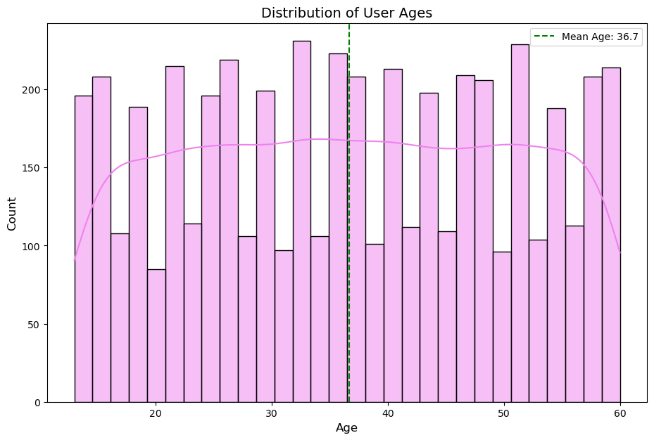

```python
## Visualisation 1: Age Distribution (Histogram with KDE)
plt.figure(figsize=(11, 7))
sns.histplot(df['Age'], bins=30, kde=True, color='Violet')
plt.title('Distribution of User Ages', fontsize=14)
plt.xlabel('Age', fontsize=12)
plt.ylabel('Count', fontsize=12)
plt.axvline(df['Age'].mean(), color='green', linestyle='--', label=f'Mean Age: {df["Age"].mean():.1f}')
plt.legend()
plt.show()
```

The graph depicts user age distributions through frequency data about different age groups.The histogram along with Kernel Density Estimate (KDE) visualization shows an accepted shape of age distribution data to identify if it follows a skew pattern or shows normal distribution. The mean age stands indicated by a green vertical line to show users how ages are positioned concerning all the data points.

```
C:\Users\Shweta Raut\AppData\Local\Temp\ipykernel_1740\3985170192.py:4: FutureWarning:

Passing `palette` without assigning `hue` is deprecated and will be removed in v0.14.0. Assign the `x` variable to `hue` and set `legend=False` for the same effect.

  sns.barplot(x=platform_counts.index, y=platform_counts.values, palette='viridis')
```

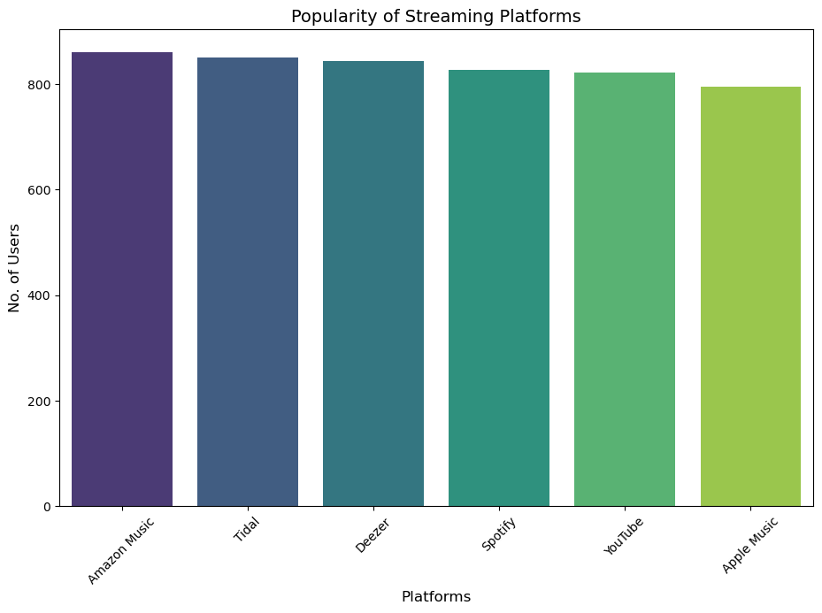

```python
## Visualisation 2: Platform Popularity (Bar Chart)
plt.figure(figsize=(11, 7))
platform_counts = df['Streaming Platform'].value_counts()
sns.barplot(x=platform_counts.index, y=platform_counts.values, palette='viridis')
plt.title('Popularity of Streaming Platforms', fontsize=14)
plt.xlabel('Platforms', fontsize=12)
plt.ylabel('No. of Users', fontsize=12)
plt.xticks(rotation=45)
plt.show()
```

This code depicts a bar chart to present the streaming platform popularity rankings through a count of user numbers from the dataset. The code applies value_counts() to count user numbers by platform before it plots this data using the viridis color palette. The vertical axis reflects user number distribution and the horizontal axis displays the platforms. The chart labels on x-axis receive an angle rotation of 45-degrees to ensure readers can understand them. The visual presentation enables users to determine popular streaming platforms because it shows how many users exist for each platform. The visualization helps users observe platform popularity directly so they can easily interpret user preference patterns.

```
C:\Users\Shweta Raut\AppData\Local\Temp\ipykernel_1740\3870511047.py:3: FutureWarning:

Passing `palette` without assigning `hue` is deprecated and will be removed in v0.14.0. Assign the `x` variable to `hue` and set `legend=False` for the same effect.

  sns.boxplot(x='Subscription Type', y='Age', data=df, palette='pastel')
```

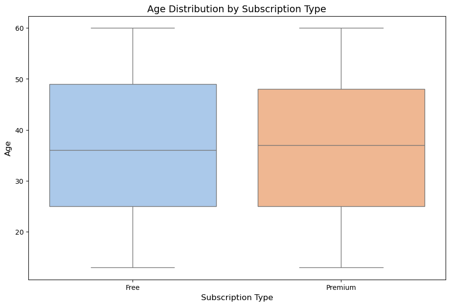

```python
## Visualisation 3: Subscription Type by Age (Box Plot)
plt.figure(figsize=(11, 7))
sns.boxplot(x='Subscription Type', y='Age', data=df, palette='pastel')
plt.title('Age Distribution by Subscription Type', fontsize=14)
plt.xlabel('Subscription Type', fontsize=12)
plt.ylabel('Age', fontsize=12)
plt.show()
```

The created box plot shows distribution patterns of user ages according to their chosen subscription types. The graphical chart contains subscription types organized along the x-axis and user ages displayed on the y-axis. Each subscription type receives representation in a box plot that includes both median values and interquartile ranges (IQRs) along with outlier detection in pastel color scales. Reviewing this visualized information helps researchers understand the age patterns that exist between subscription types. The visual presents central tendencies, age spreads and outside points in age across different subscription types which helps understand user demographic characteristics by subscription category.

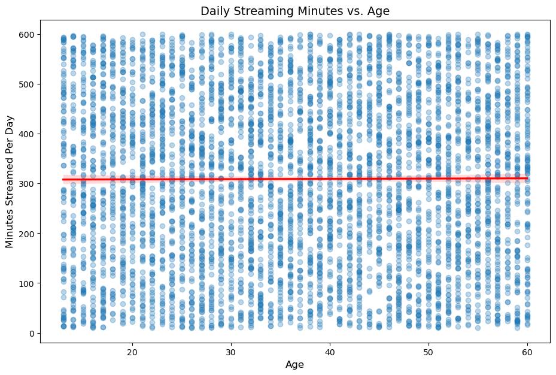

```python
## Visualisation 4: Daily Streaming Minutes vs. Age (Scatter Plot with Regression)
plt.figure(figsize=(11, 7))
sns.regplot(x='Age', y='Minutes Streamed Per Day', data=df, scatter_kws={'alpha':0.3}, line_kws={'color':'red'})
plt.title('Daily Streaming Minutes vs. Age', fontsize=14)
plt.xlabel('Age', fontsize=12)
plt.ylabel('Minutes Streamed Per Day', fontsize=12)
plt.show()
```

A scatter plot includes a regression line which analyzes the age vs daily streaming time relationship of users. The regplot function shows data points while using transparency (alpha=0.3) but also adds a red regression line to illustrate the connection between variables. The visual presentation allows us to study how age relates to streaming duration each day. The visualization reveals age-related streaming patterns because it detects any existing data clusters among different user demographics. Also it provides a straightforward representation of streaming activity alterations across age groups.

```
C:\Users\Shweta Raut\AppData\Local\Temp\ipykernel_1740\2460040050.py:4: FutureWarning:

Passing `palette` without assigning `hue` is deprecated and will be removed in v0.14.0. Assign the `y` variable to `hue` and set `legend=False` for the same effect.

  sns.barplot(x=top_genres.values, y=top_genres.index, palette='rocket')
```

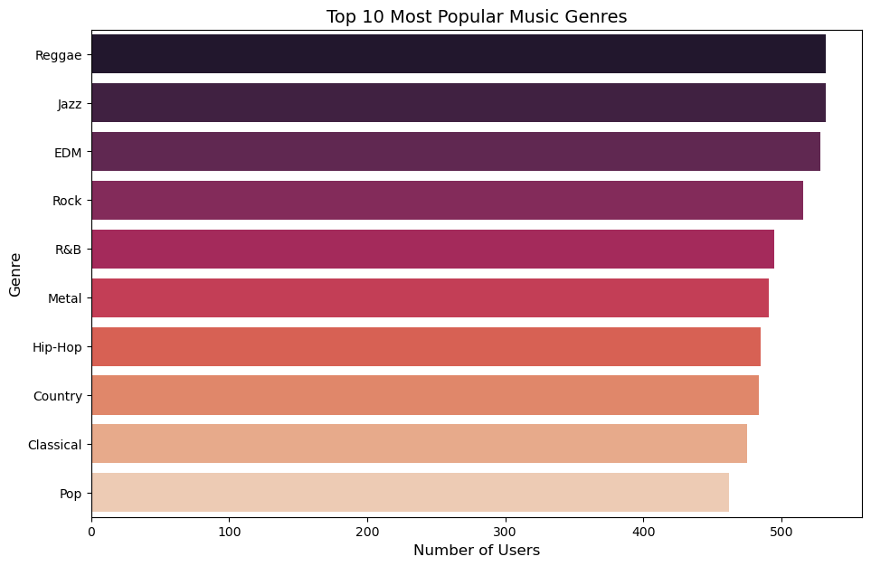

```python
## Visualisation 5: Top Genres (Horizontal Bar Chart)
plt.figure(figsize=(11, 7))
top_genres = df['Top Genre'].value_counts().nlargest(14)
sns.barplot(x=top_genres.values, y=top_genres.index, palette='rocket')
plt.title('Top 10 Most Popular Music Genres', fontsize=14)
plt.xlabel('Number of Users', fontsize=12)
plt.ylabel('Genre', fontsize=12)
plt.show()
```

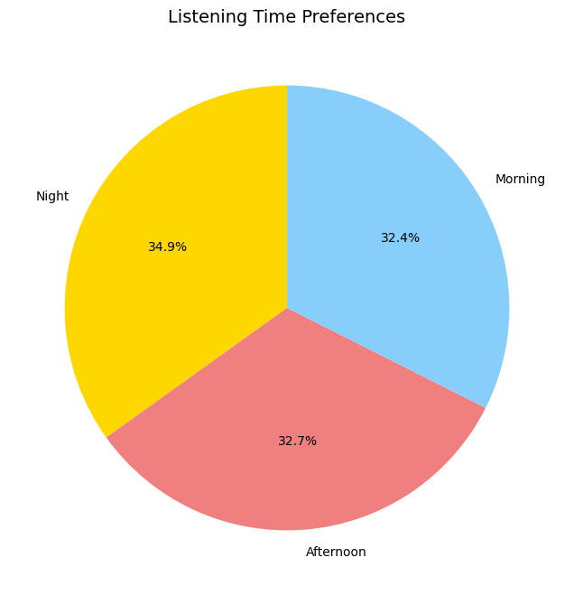

```python
## Visualisation 6: Listening Time Preferences (Pie Chart)
plt.figure(figsize=(8, 8))
listening_time = df['Listening Time (Morning/Afternoon/Night)'].value_counts()
plt.pie(listening_time, labels=listening_time.index, autopct='%1.1f%%',
        colors=['gold', 'lightcoral', 'lightskyblue'], startangle=90)
plt.title('Listening Time Preferences', fontsize=14)
plt.show()
```

The written code generates a pie chart which demonstrates how users allocate their time for listening to music between morning, afternoon and night periods. The value_counts() function generates preference occurrence counts which the pie chart displays through colored segments showing proportion percentages. The graphic provides essential knowledge about when user groups listen most frequently to music. The code reveals user listening habits throughout the day thus helping businesses determine their most active times to schedule content and marketing materials.

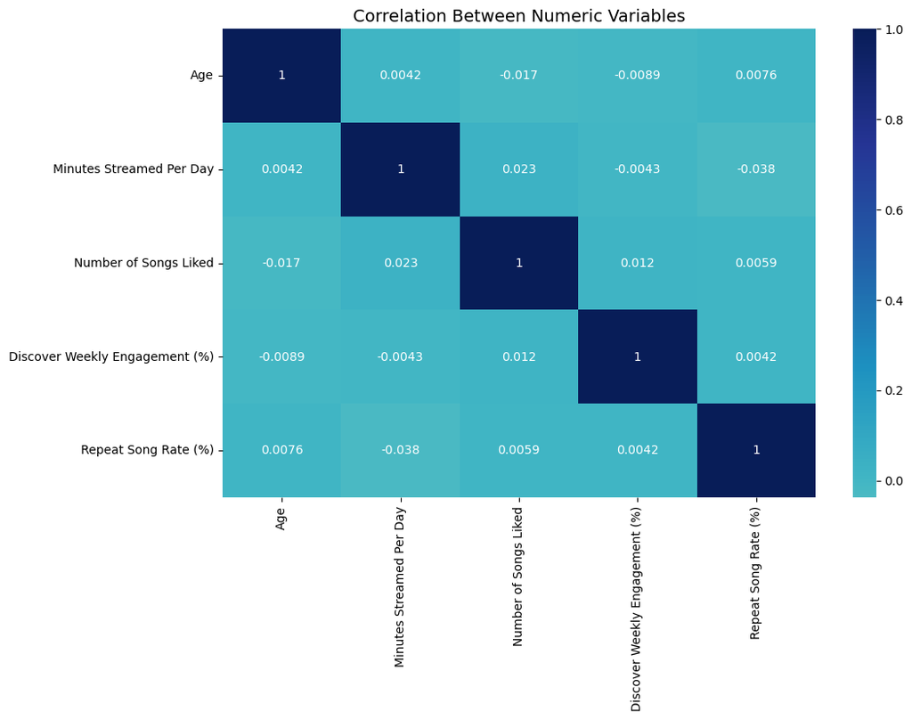

```python
#Visualisation 7: Correlation Heatmap
plt.figure(figsize=(11, 7))
corr = df[numeric_cols].corr()
sns.heatmap(corr, annot=True, cmap='YlGnBu', center=0)
plt.title('Correlation Between Numeric Variables', fontsize=14)
plt.show()
```

Through this code a heatmap appears to show the numeric variable correlation metrics within the dataset. The selected numeric columns receive computing of correlation values from the corr() function before presenting them through a heatmap using a color scheme 'YlGnBu'. The table cells include precise correlative value annotations. The correct display of numeric variable relationships depends on clear visualization. The correlation analysis reveals the strength of variable relations through its assessment of relationships which enables planners to make decisions regarding future modeling work or feature choice.

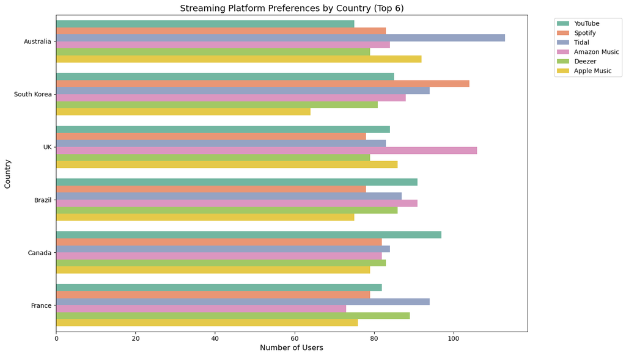

```python
# Additional advanced visualisation: Streaming Platform Preferences by Country (Facet Grid)
top_countries = df['Country'].value_counts().nlargest(6).index.tolist()
df_top_countries = df[df['Country'].isin(top_countries)]

plt.figure(figsize=(14, 8))
sns.countplot(y='Country', hue='Streaming Platform', data=df_top_countries,
              order=top_countries, palette='Set2')
plt.title('Streaming Platform Preferences by Country (Top 6)', fontsize=14)
plt.xlabel('Number of Users', fontsize=12)
plt.ylabel('Country', fontsize=12)
plt.legend(bbox_to_anchor=(1.05, 1), loc='upper left')
plt.tight_layout()
plt.show()
```

A count plot shows the streaming platform preferences among users by country with special attention to the six nations that have the largest number of users. A countplot shows the user quantities split into different streaming platforms using distinct colors which separate each platform's data by nation. The plot utilizes 'Set2' colors to present the countries organized by user numbers in descending order. A proper visualization method helps to display the variations in streaming platform choices across different countries. The most popular streaming platforms across the top 6 countries become evident here which enables valuable breakthroughs regarding regional market strategies and platform-specific marketing activities and content targeting techniques.

## Summary of Analysis and Findings(415 Words)

### Key Information About the Data

- The dataset includes 12 columns that contain a total of 5,000 entries and shows a validation check revealing consistency and absence of missing or inconsistent values.

The dataset contains three data types consisting of integers (age and minutes streamed per day), floats (discover weekly engagement and repeat song rate) and objects (country and streaming platform)

According to summary statistics the user base consists of 36.66-year-old participants spending 309.24 minutes daily while liking 253.52 songs on average. The average discover weekly engagement stands at 50.30% and users listen to their favorite songs again at a rate of 42.39%.

### Statistically Significant Results

- The correlation investigation among numerical fields (age and minutes streamed per day and number of songs liked and discover weekly engagement and repeat song rate) demonstrated low correlation rates without showing noteworthy linear patterns. The calculated correlation value between age and daily streaming duration measured 0.004 which implied little relationship between these variables.
- The numerical data contains no outliers or impossible values within its columns. The dataset includes categories such as country and streaming platform which show appropriate and uniform values.

### Conclusion

The research study determined three main music streaming patterns namely the average user age at 36.7 and the top platforms as Amazon Music and Tidal alongside the most preferred genres as Reggae and Jazz.Age groups did not show any significant relationship patterns when it comes to music listener behaviors. The frequency split between premium (50%) consumers together with knowledge about peak usage hours at night can help streaming businesses optimize their marketing strategies while improving individual user interactions.